# M5 Data Analysis Solutions

Arvon Clemons II

10/11/2020

# Part 1. Representation in Research

## Numerical and Graphical Summary

```r
tbl1 <- tibble("Race/Ethnicity" = c("Distribution of Pop", "Number in Lung Cancer Trial"),
       "American Indian/Alaska Native"=c(0.007, 12),
       "Asian/Pacific Islander"=c(0.038, 54),
       "Black"=c(0.108, 316),
       "Hispanic" = c(0.091, 60),
       "White non-Hispanic" = c(0.756, 3855)
)
knitr::kable(tbl1)
```

| Race/Ethnicity | American Indian/Alaska Native | Asian/Pacific Islander | Black | Hispanic | White non-Hispanic |
| --- | --- | --- | --- | --- | --- |
| Distribution of Pop | 0.007 | 0.038 | 0.108 | 0.091 | 0.756 |
| Number in Lung Cancer Trial | 12.000 | 54.000 | 316.000 | 60.000 | 3855.000 |

```r
Expected <- lungcancer$race %>%
  as.factor %>%
  levels() %>%
  rep(sum(tbl1[2, -1]) * unlist(tbl1[1, -1])) %>% sample() %>% as_tibble()
colnames(Expected) <- "race"

exp1 <- Expected %>%
  group_by(race) %>%
  tally(name = "Expected_Count")

(obs1 <- lungcancer %>%
   group_by(race) %>%
   tally(name = "Observed_Count") %>%
   mutate(Enrolled_Prop = Observed_Count / sum(Observed_Count)) %>% left_join(exp1, by = "race")
  )
```

```
## # A tibble: 5 x 4
##   race       Observed_Count Enrolled_Prop Expected_Count
##   <chr>               <int>         <dbl>          <int>
## 1 AmericanIn             12       0.00279             30
## 2 Asian                  54       0.0126             163
## 3 Black                 316       0.0735             464
## 4 Hispanic               60       0.0140             391
## 5 White                3855       0.897             3248
```

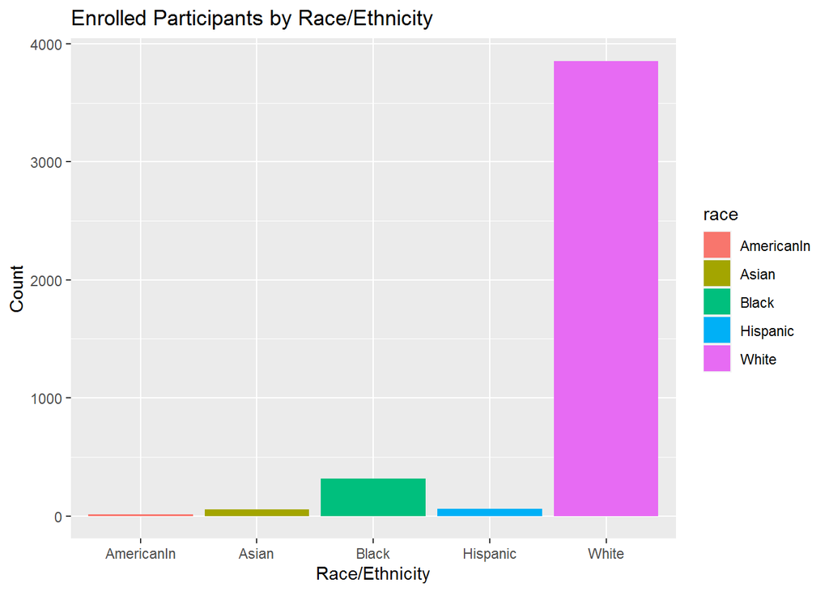

```r
ggplot(lungcancer, aes(x = race, fill = race)) +
  geom_bar() +
  ggtitle("Enrolled Participants by Race/Ethnicity") +
  xlab("Race/Ethnicity") +
  ylab("Count")
```

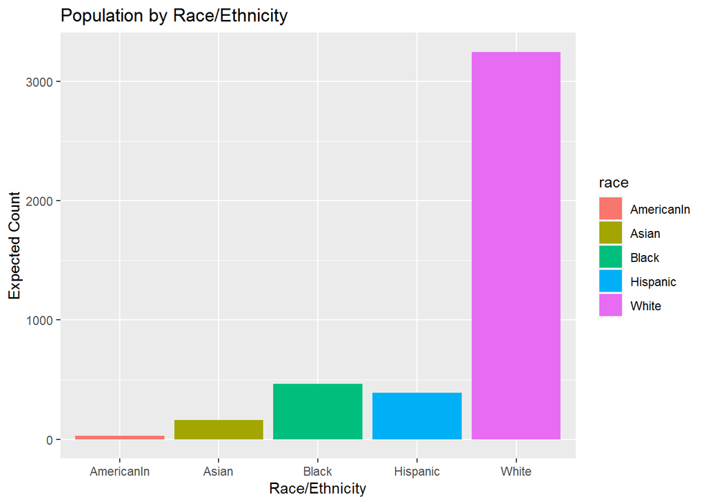

```r
ggplot(Expected, aes(x = race, fill = race)) +
  geom_bar() +
  ggtitle("Population by Race/Ethnicity") +
  xlab("Race/Ethnicity") +
  ylab("Expected Count")
```

## Hypothesis and Conditions

The aim of the research is to investigate whether race/ethnicity are being over or under represented in clinical trials. In order for any group to be disproportionally represented would require that such at least one group be enrolled in clinical trials at a proportion differing from the population.

The conditions that are required for this are the following: 1. The data come from a simple random sample 2. The expected count is at least 5 for each group

The data we have fits both of the conditions and as such we proceed with test.

## Hypothesis Testing

```r
set.seed(123)
(testGOF <- chisq.test(table(lungcancer), p=unlist(tbl1[1, -1]),correct = F))
```

```
##
##  Chi-squared test for given probabilities
##
## data:  table(lungcancer)
## X-squared = 524.71, df = 4, p-value < 2.2e-16
```

```r
(cvGOF <- qchisq(p = 1 - 0.01, df = 4))
```

```
## [1] 13.2767
```

As can be seen above, the test statistic from the above is 524.7132369 which is much greater than our calculated critical value of 13.2767041, this is in combination with the p-value of 3.0210^{-112} which is very much smaller than our significance level of 0.01.

## Conclusion

Given the above test results one should conclude that there sufficient evidence to reject the null hypothesis and thus conclude that in the true population there is disproportionate participation in lung cancer clinical trials by race/ethnicity.

# Part 2. Mammography

## Data Summary

```r
mamexp %>%
  select(me, famhist) %>%
  table() %>% knitr::kable()
```

|  | no | yes |
| --- | --- | --- |
| never | 220 | 14 |
| >1 year | 63 | 11 |
| <1 year | 85 | 19 |

## Hypothesis and Conditions

The aim of this research is to identify whether or not there is a dependent relationship between an womans’ experience with mammography and having a family history of breast cancer. The variables used in this study are both categorical: (1) mammography experience (never, within one year, over one year ago), (2)mother or sister with a history of breast cancer (no, yes).

This suggests that the best method to use for this research question would be the chi-square Test of Independence. The conditions for this test are the following: 1. The data come from a simple random sample 2. The expected count is at least 5 for each group

```r
(tableOBS <- mamexp %>%
  select(me, famhist) %>%
  table() %>% addmargins())
```

```
##          famhist
## me         no yes Sum
##   never   220  14 234
##   >1 year  63  11  74
##   <1 year  85  19 104
##   Sum     368  44 412
```

```r
tableEXP <- matrix(NA, nrow = 3, ncol = 2, dimnames = list(c("never", ">1 year", "<1 year"), c("no", "yes")))

for(i in 1:3){
  for(j in 1:2){
    tableEXP[i, j] <- (tableOBS[i, 3] * tableOBS[4, j]) / tableOBS[4, 3]
  }
}
tableEXP
```

```
##                no       yes
## never   209.00971 24.990291
## >1 year  66.09709  7.902913
## <1 year  92.89320 11.106796
```

As we can see from the above table, there is indeed at least 5 counts for each group and we assume the sampling was a simple random.

The hypotheses for this test would be $H_0:$ Distribution of “no/yes” responses for Family History are independent of “never, <1 year, >1 year” responses for Mammography Experience and $H_1:$ Distribution of “no/yes” responses for Family History are NOT independent of “never, <1 year, >1 year” responses for Mammography Experience.

## Hypothesis Testing

```r
(testIND <- chisq.test(mamexp$me, mamexp$famhist, correct = FALSE))
```

```
##
##  Pearson's Chi-squared test
##
## data:  mamexp$me and mamexp$famhist
## X-squared = 13.05, df = 2, p-value = 0.001466
```

```r
(cvIND <- qchisq(p = 1 - 0.10, df = 2))
```

```
## [1] 4.60517
```

As can be seen above, the test statistic from the above is 13.0501885 which is much greater than our calculated critical value of 4.6051702, this is in combination with the p-value of 0.00147 which is very much smaller than our significance level of 0.10. As such we would assess that there is sufficient evidence to REJECT the null hypothesis.

## Conclusion

Given the above test results one should conclude that there sufficient evidence to reject the null hypothesis and thus conclude that in the true population there is a dependent relationship between mammography experience and family history of breast cancer.

# Part 3. Hip Protectors

## Hypothesis and Conditions

The researchers are interested in whether or not hip protectors protect against hip fractures, using individuals that are wearing hip protectors on one hip but not the other.

Since the proportions of comparison are the hips on a single individual, one unprotected and another protected, for the same event of falling and possibly receiving a fracture this would be a clear example of a dependent hypothesis test as one outcome isn’t entirely unrelated to the other.

The hip protectors (while left unsaid) are switched for the participants, so the contigency table is a pair off yes/no responses. As such the most appropriate test for this would be McNemar’s Test.

```r
(tableMCN <- matrix(data = c(309, 15, 324, 10, 2, 12, 319, 17, 336),nrow = 3, ncol = 3, dimnames = list(c("Non-Fractured", "Fractured", "Sum"), c("Non-Fractured", "Fractured", "Sum"))))
```

```
##               Non-Fractured Fractured Sum
## Non-Fractured           309        10 319
## Fractured                15         2  17
## Sum                     324        12 336
```

In this test our hypotheses would be $H_0: p_b = p_c$ and $H_1: p_b \neq p_c$. With $p_b$ being the true proportion of “successes” in the first observation and “failures” in the second observation and $p_c$ being the true proportion of “failures” in the first observation and “successes” in the second observation.

In other words, the null hypothesis is that the true proportion of fractured right hips while the protector was worn on the left hip and the true proportion of fractured left hips while the protector was worn on the right hip are equal, with the alternative hypothesis being that this is unequal.

The conditions for this test are the following: 1: Simple Random Sample 2: $b + c \geq 10$

We assume the researchers conducted a Simple Random Sample and as we can see from the table above, the counts in B (10) and C(15) total to 25 and thus indeeds are equal to or greater than 10.

## Hypothesis Testing

```r
(testMCN <- mcnemar.test(tableMCN[-3, -3], correct = F))
```

```
##
##  McNemar's Chi-squared test
##
## data:  tableMCN[-3, -3]
## McNemar's chi-squared = 1, df = 1, p-value = 0.3173
```

```r
(cvMCN <- qchisq(p = 1 - 0.05, df = 1))
```

```
## [1] 3.841459
```

As can be seen above, the test statistic from the above is 1 which is lesser than our calculated critical value of 3.8414588, this is in combination with the p-value of 0.317 which is larger than our significance level of 0.05. As such we would assess that there is not enough sufficient evidence and therefore we FAIL TO REJECT the null hypothesis.

## Conclusion

We are forced to assume that the true proportion of hip fractures are equal between wearing them or not.